# Russian housing price influence factors and forecast

## Project Introduction

### Introduction

无论是在任何时期，住房都是人们生活最基本的需求，与人们的日常生活息息相 关。飞速发展的房地产市场已成为推动经济增长、拉动内需的基础性支柱产业，在国民 经济发展中扮演着重要角色。房地产行业的发展状况是关系国计民生的重要问题， 房价是房产的市场价值，其对人们的生活水平和国民经济发展有着很大的影响。房价的研究已受到统计学、管理学、计算机科学等多个领域的重点关注，房价的预测也成为许多学者研究探讨的问题。顺应大数据和机器学习的发展趋势， 结合网络数据，利用数据挖掘及机器学习算法分析预测房价问题更具科学性。

At any given time, housing is the most basic need of human's live and it is closely linked to their daily lives. The rapidly developing real estate market has become a fundamental pillar industry driving economic grwth and domestic demand, and plays an important role in the development of the nationa economy.The development status of the real estate industry is an important issue that affects the livelihood of the nation. House price is the market value of property, which has a great impact on people's living standard and national economic development.The development status of the real estate industry is an important issue that affects the livelihood of the nation.House price is the market value of property, which has a great impact on people's living standard and national economic development.The study of house prices has received key attention from a number of fields such as statistics, management and computer science, and the prediction of house prices has become a problem for many scholars to study and explore. In line with the development trend of big data and machine learning, it is more scientific to use data mining and machine learning algorithms to analyze and predict house prices by combining web data.

### Literature review

针对影响因素构建预测模型对房价进行预测分为两个角度：一个是从宏观经济角度出发，利用GDP、贷款利率等宏观指标对平均房价进行预测。另一个是从房屋自身角度出发，根据房屋自身特征因素对具体房屋的房价进行预测[1];Rosen等[2]首次将特征价格(Hedonic)理论引入到房价预测中，并提出了住宅特征模型，该模型第一次研究了住宅价格与居住环境的关系;Chia-Chen Fan等[3]建立了房价预测和房屋信息销售的网络服 务系统，该系统结合分析方法和预测模型来预测房价;Naalla Vineeth等通过使用机器学习算法中的简单线性回归、多元线性回归和神经网络建立房价预测模型，用于帮助买卖双方找到房子的最佳价格[4]

The construction of forcesting models to predict house prices is usually divided into two perspectives. One is from a macroeconomic perspective, using macro indicators such as GDP and lending rates to make forecasts of average house prices. The other one is the prediction of house prices based on the house's own features[1]; Rosen et al [2] first introduced the characteristic price (Hedonic) theory to house price forecasting and proposed a residential characteristic model, which first investigated the relationship between residential prices and living environment.Chia-Chen Fan et al [3] developed a web service system for house price forecasting and housing information sales, which combines analytical methods and forecasting models to predict house prices. Naalla Vineeth build house price prediction models through the use of simple linear regression, multiple linear regression and neural networks in machine learning algorithms for helping buyers and sellers find the best price for a house [4]

### Research question

针对当前房地产价格预测精度低的难题,俄羅斯最早，最大的銀行Sberbank希望通過預測房地產價格來幫助客戶做出更好的决策; 在这个项目当中，我们利用Sberbank提供的住房市场数据，对影响房地产价格的各种因素进行分析，如房屋因素(楼层高度、面积大小等)、所在区域、附近环境(地铁、超市、学校等)、购房目的等，综合分析房屋价格的波动情况，进而寻求房价与购买时各属性间的关联关系，并利用机器学习回归及分类模型进行建模预测房地产价格，对房屋价格估值,为房屋出售者和房屋购买者提供科学的参考依据。因此，该项目的研究问题是“房屋特征因素与房屋价格波动之间的关系是什么”

Addressing the current challenges of low accuracy in property price forecasting, the first and largest bank in Russia, Sberbank, wants to help its customers make better decisions by predicting real estates prices better.

In this article, housing market data provided by Sberbank will be used, producing an analysis of the various factors affecting the price of real estate, such as floor height, located area, the nearby environment and amenities (subways, supermarkets, schools) and the purpose of the purchase, and analysing the fluctuations in housing prices in a comprehensive manner, to seek a correlation between houses and each attributes at the time of purchase, it also uses regression and classification models to model and predict real estate prices and provide a scientific reference for property sellers and buyers. Therefore, the research question of the project is " What is the relationship between housing characteristics factors and housing price fluctuations?"

## Presentation of data

数据来源：https://www.kaggle.com/c/sberbank-russian-housing-market/overview 该数据来自Sberbank提供的住房市场数据，目标变量在数据中称为price_doc，数据截取的时间区间为2011年8月至2015年6月，包含销售价格、住房面积、建筑楼层等特征

Data sourced: https://www.kaggle.com/c/sberbank-russian-housing-market/overview The data is taken from housing market data provided by Sberbank, the target variable is referred to as price_doc in the data, the data is intercepted from August 2011 to June 2015 and contains features such as price, housing area, building floors.

```python
import pandas as pd
import numpy as np
import seaborn as sns
import matplotlib.pyplot as plt
import warnings
import missingno as msno
sns.set()
%matplotlib inline
warnings.filterwarnings('ignore')
```

```python
pd.set_option('display.max_columns', None)
```

```python
plt.rcParams['font.sans-serif'] = ['Microsoft YaHei']  # 用来正常显示中文标签
plt.rcParams['axes.unicode_minus'] = False
```

### 加载数据与预览数据 Loading Data and previewing data

```python
train_data = pd.read_csv("train.csv", header=0,encoding='utf8')
```

```python
train_data.shape
```

```
(30471, 292)
```

```python
train_data.head()
```

|  | id | timestamp | full_sq | life_sq | floor | max_floor | material | build_year | num_room | kitch_sq | state | product_type | sub_area | area_m | raion_popul | green_zone_part | indust_part | children_preschool | preschool_quota | preschool_education_centers_raion | children_school | school_quota | school_education_centers_raion | school_education_centers_top_20_raion | hospital_beds_raion | healthcare_centers_raion | university_top_20_raion | sport_objects_raion | additional_education_raion | … |
| --- | --- | --- | --- | --- | --- | --- | --- | --- | --- | --- | --- | --- | --- | --- | --- | --- | --- | --- | --- | --- | --- | --- | --- | --- | --- | --- | --- | --- | --- | --- |
| 0 | 1 | 2011-08-20 | 43 | 27.0 | 4.0 | NaN | NaN | NaN | NaN | NaN | NaN | Investment | Bibirevo | 6.407578e+06 | 155572 | 0.189727 | 0.000070 | 9576 | 5001.0 | 5 | 10309 | 11065.0 | 5 | 0 | 240.0 | 1 | 0 | 7 | 3 | … |
| 1 | 2 | 2011-08-23 | 34 | 19.0 | 3.0 | NaN | NaN | NaN | NaN | NaN | NaN | Investment | Nagatinskij Zaton | 9.589337e+06 | 115352 | 0.372602 | 0.049637 | 6880 | 3119.0 | 5 | 7759 | 6237.0 | 8 | 0 | 229.0 | 1 | 0 | 6 | 1 | … |
| 2 | 3 | 2011-08-27 | 43 | 29.0 | 2.0 | NaN | NaN | NaN | NaN | NaN | NaN | Investment | Tekstil'shhiki | 4.808270e+06 | 101708 | 0.112560 | 0.118537 | 5879 | 1463.0 | 4 | 6207 | 5580.0 | 7 | 0 | 1183.0 | 1 | 0 | 5 | 1 | … |
| 3 | 4 | 2011-09-01 | 89 | 50.0 | 9.0 | NaN | NaN | NaN | NaN | NaN | NaN | Investment | Mitino | 1.258354e+07 | 178473 | 0.194703 | 0.069753 | 13087 | 6839.0 | 9 | 13670 | 17063.0 | 10 | 0 | NaN | 1 | 0 | 17 | 6 | … |
| 4 | 5 | 2011-09-05 | 77 | 77.0 | 4.0 | NaN | NaN | NaN | NaN | NaN | NaN | Investment | Basmannoe | 8.398461e+06 | 108171 | 0.015234 | 0.037316 | 5706 | 3240.0 | 7 | 6748 | 7770.0 | 9 | 0 | 562.0 | 4 | 2 | 25 | 2 | … |

可以看到数据集中有292个变量，为了让探索性分析更加清晰明了，我从其中挑选一些重要得特征。 From the above table, there are 292 variables in the dataset, some important features will be picked in order to make the exploratory analysis clear.

```python
data = train_data[['price_doc','timestamp','full_sq','life_sq','kitch_sq','floor','max_floor','material','build_year',
                   'num_room','state','product_type','sub_area','area_m','raion_popul','park_km','metro_km_walk','stadium_km',
                   'work_all','railroad_km','school_km','big_market_raion','metro_min_avto','additional_education_km','metro_km_avto','cafe_count_5000','public_healthcare_km','big_market_km','public_transport_station_km','theater_km','catering_km','green_zone_km','market_shop_km','ttk_km','kindergarten_km','workplaces_km','oil_chemistry_km','big_road2_km']]
```

Variable Description：

[output not shown]

### 数据预处理 Data wrangling

#### 缺失值 Missing value

```python
data.info()
```

```
<class 'pandas.core.frame.DataFrame'>
RangeIndex: 30471 entries, 0 to 30470
Data columns (total 38 columns):
 #   Column                       Non-Null Count  Dtype
---  ------                       --------------  -----
 0   price_doc                    30471 non-null  int64
 1   timestamp                    30471 non-null  object
 2   full_sq                      30471 non-null  int64
 3   life_sq                      24088 non-null  float64
 4   kitch_sq                     20899 non-null  float64
 5   floor                        30304 non-null  float64
 6   max_floor                    20899 non-null  float64
 7   material                     20899 non-null  float64
 8   build_year                   16866 non-null  float64
 9   num_room                     20899 non-null  float64
```

[output cut: 30 more lines]

```python
#Detect which columns have missing values
data.isnull().any()
```

```
price_doc                      False
timestamp                      False
full_sq                        False
life_sq                         True
kitch_sq                        True
floor                           True
max_floor                       True
material                        True
build_year                      True
num_room                        True
state                           True
product_type                   False
sub_area                       False
area_m                         False
raion_popul                    False
park_km                        False
metro_km_walk                   True
stadium_km                     False
work_all                       False
railroad_km                    False
school_km                      False
big_market_raion               False
metro_min_avto                 False
additional_education_km        False
metro_km_avto                  False
cafe_count_5000                False
public_healthcare_km           False
big_market_km                  False
public_transport_station_km    False
theater_km                     False
catering_km                    False
green_zone_km                  False
market_shop_km                 False
ttk_km                         False
kindergarten_km                False
workplaces_km                  False
oil_chemistry_km               False
big_road2_km                   False
dtype: bool
```

```python
#Count how many columns have missing values
data.isnull().any().value_counts()
```

```
False    29
True      9
dtype: int64
```

It can be noticed that among the selected features, there are 9 columns with null values.

```python
#Check if any columns are all null values
data.isnull().all().value_counts()
```

```
False    38
dtype: int64
```

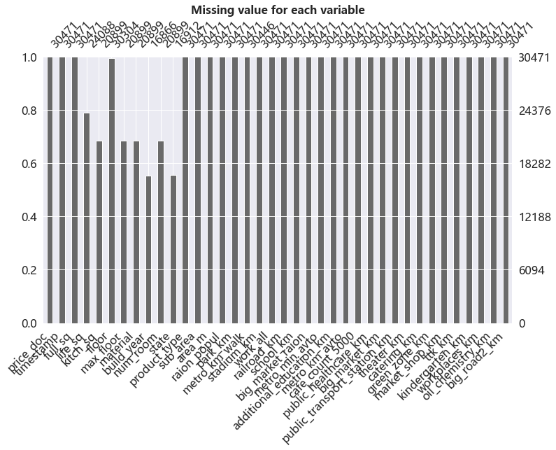

```python
msno.bar(data.sample(data.shape[0]), figsize=(12, 7), )
plt.title('Missing value for each variable',fontweight = 'black',fontsize = 16)
plt.show()
```

```python
#Percentage of missing values
((data.isnull().sum())/data.shape[0]).sort_values(ascending=False).map(lambda x:"{:.2%}".format(x))
```

```
build_year                     44.65%
state                          44.50%
kitch_sq                       31.41%
max_floor                      31.41%
material                       31.41%
num_room                       31.41%
life_sq                        20.95%
floor                           0.55%
metro_km_walk                   0.08%
price_doc                       0.00%
public_healthcare_km            0.00%
big_market_km                   0.00%
public_transport_station_km     0.00%
theater_km                      0.00%
catering_km                     0.00%
workplaces_km                   0.00%
green_zone_km                   0.00%
market_shop_km                  0.00%
ttk_km                          0.00%
kindergarten_km                 0.00%
metro_km_avto                   0.00%
oil_chemistry_km                0.00%
cafe_count_5000                 0.00%
railroad_km                     0.00%
additional_education_km         0.00%
metro_min_avto                  0.00%
big_market_raion                0.00%
school_km                       0.00%
timestamp                       0.00%
work_all                        0.00%
stadium_km                      0.00%
park_km                         0.00%
raion_popul                     0.00%
area_m                          0.00%
sub_area                        0.00%
product_type                    0.00%
full_sq                         0.00%
big_road2_km                    0.00%
dtype: object
```

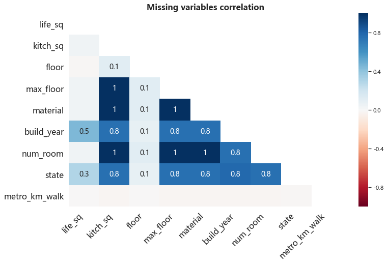

```python
msno.heatmap(data.sample(data.shape[0]),figsize=(12, 7), )
plt.title('Missing variables correlation',fontweight = 'black',fontsize = 16)
plt.show()
```

可以看到 It can be observed that

1、当“kitch_sq”缺失时，“max_floor”、“material”、“numroom”也一定缺失，可以确定，这个特征中的缺失值是同时缺失。 When "kitch_sq" is missing, "max_floor", "material" and "numroom " must also be missing, it can be determined that there is a strong correlation between these 4 features. 2、当“max_floor”缺失时，“material”、“numroom”也一定缺失，而“state”和“build_year”则有80%可能也缺失。 When "max_floor" is missing, "material" and "numroom" must also be missing, and there is an 80% chance that "state" and "build_year" are also missing. 3、当“floor”缺失值，与其它具有缺失值的特征都没有相关性。 When "floor" has a missing value, there is no correlation with any other feature that has a missing value.

```python
#Dealing with missing values
data['build_year'] = data['build_year'].fillna('-1').astype('float64')
data['state'] = data['state'].fillna('-1').astype('float64')
data['num_room'] = data['num_room'].fillna('-1').astype('float64')
data['kitch_sq'] = data['kitch_sq'].fillna('-1').astype('float64')
data['max_floor'] = data['max_floor'].fillna('-1').astype('float64')
data['material'] = data['material'].fillna('-1').astype('float64')
```

```python
# Filled Median
data['floor'] = data['floor'].fillna(data['floor'].median()) .astype('float64')
data['metro_km_walk'] = data['metro_km_walk'].fillna(data['metro_km_walk'].median()).astype('float64')
```

```python
data.info()
```

```
<class 'pandas.core.frame.DataFrame'>
RangeIndex: 30471 entries, 0 to 30470
Data columns (total 38 columns):
 #   Column                       Non-Null Count  Dtype
---  ------                       --------------  -----
 0   price_doc                    30471 non-null  int64
 1   timestamp                    30471 non-null  object
 2   full_sq                      30471 non-null  int64
 3   life_sq                      24088 non-null  float64
 4   kitch_sq                     30471 non-null  float64
 5   floor                        30471 non-null  float64
 6   max_floor                    30471 non-null  float64
 7   material                     30471 non-null  float64
 8   build_year                   30471 non-null  float64
 9   num_room                     30471 non-null  float64
```

[output cut: 30 more lines]

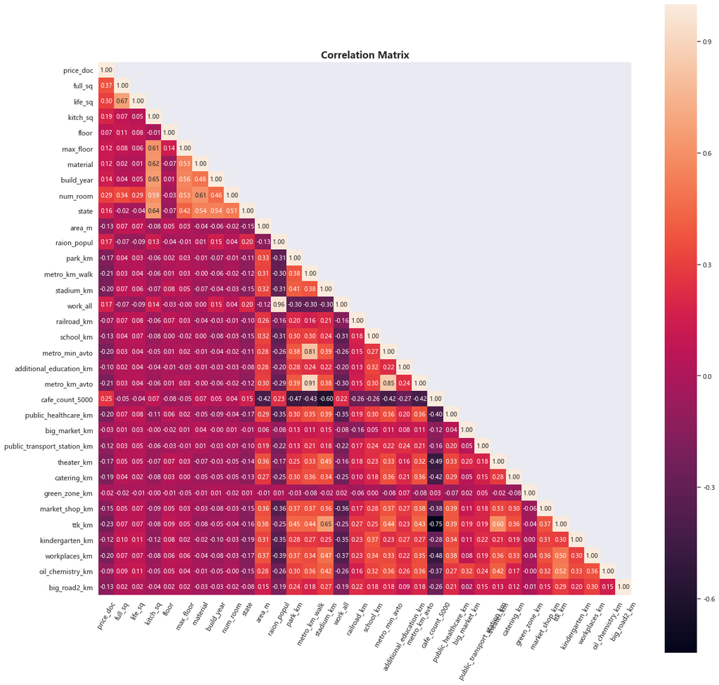

```python
corr= data.corr(method='kendall')
plt.figure(figsize=(20,20))
mask = np.array(corr)
mask[np.tril_indices_from(mask)] = False
sns.heatmap(corr,annot=True,square=True,mask=mask,fmt=".2f")
plt.xticks(rotation=60)
plt.title('Correlation Matrix',fontweight = 'black',fontsize = 16)
plt.show()
```

```python
from sklearn.ensemble import RandomForestRegressor

def fill_missing(data,to_fill):
    '''
    data:数据集
    to_fill:需要填补的特征列
    '''
    # 构建新的特征和标签
    df = data.copy()
    columns = ['price_doc','full_sq','life_sq','num_room','metro_km_walk','stadium_km']
    columns.remove(to_fill)    # 将需要预测的标签移除
    # 移除有缺失值的列
#     print(columns)
    # 提取特征和标签，并划分训练集和测试集，训练集指的是月收入中没有缺失值的样本，测试集指的是需要预测的缺失值的样本
    X = df.loc[:,columns]  # 特征
    y = df.loc[:,to_fill]  # 标签
    Xtrain = X.loc[df[to_fill].notnull()]  # 训练数据
    Xtest = X.loc[df[to_fill].isnull()]   # 测试数据
    Ytrain = y.loc[df[to_fill].notnull()]
    model = RandomForestRegressor(n_estimators=200,max_depth=3,n_jobs=-1,random_state=0)
    model.fit(Xtrain,Ytrain)
    # 预测
    pred = model.predict(Xtest).round()
    # 进行填补
    df.loc[df[to_fill].isnull(),to_fill] = pred
    return df


# new_data = fill_missing(data,'life_sq')
new_data = data
```

在上面，我对缺失值进行了一系列操作 In the above code block, a series of operations performed on the missing values.

#### 异常值 Outlier

```python
new_data.describe()
```

|  | price_doc | full_sq | life_sq | kitch_sq | floor | max_floor | material | build_year | num_room | state | area_m | raion_popul | park_km | metro_km_walk | stadium_km | work_all | railroad_km | school_km | metro_min_avto | additional_education_km | metro_km_avto | cafe_count_5000 | public_healthcare_km | big_market_km | public_transport_station_km | theater_km | catering_km | green_zone_km | market_shop_km | … |
| --- | --- | --- | --- | --- | --- | --- | --- | --- | --- | --- | --- | --- | --- | --- | --- | --- | --- | --- | --- | --- | --- | --- | --- | --- | --- | --- | --- | --- | --- | --- |
| count | 3.047100e+04 | 30471.000000 | 24088.000000 | 30471.000000 | 30471.000000 | 30471.000000 | 30471.000000 | 3.047100e+04 | 30471.000000 | 30471.000000 | 3.047100e+04 | 30471.000000 | 30471.000000 | 30471.000000 | 30471.000000 | 30471.000000 | 30471.000000 | 30471.000000 | 30471.000000 | 30471.000000 | 30471.000000 | 30471.000000 | 30471.000000 | 30471.000000 | 30471.000000 | 30471.000000 | 30471.000000 | 30471.000000 | 30471.000000 | … |
| mean | 7.123035e+06 | 54.214269 | 34.403271 | 4.074924 | 7.664386 | 8.299629 | 0.939024 | 1.697753e+03 | 0.995734 | 0.724459 | 1.765705e+07 | 84056.425552 | 3.099942 | 3.559943 | 9.436658 | 53667.908897 | 1.889380 | 1.323956 | 4.961273 | 1.328488 | 3.701464 | 265.528470 | 3.356771 | 13.283916 | 0.414136 | 9.638074 | 0.687988 | 0.300511 | 3.958882 | … |
| std | 4.780111e+06 | 38.031487 | 52.285733 | 23.659478 | 5.306094 | 8.421495 | 1.796312 | 1.148704e+05 | 1.523791 | 1.677557 | 2.064961e+07 | 57871.285899 | 3.965363 | 5.773136 | 7.642037 | 37483.559701 | 1.972818 | 3.058145 | 6.553515 | 1.526219 | 5.808432 | 514.538671 | 4.341804 | 8.497170 | 1.272488 | 7.112284 | 0.832922 | 0.298402 | 3.447536 | … |
| min | 1.000000e+05 | 0.000000 | 0.000000 | -1.000000 | 0.000000 | -1.000000 | -1.000000 | -1.000000e+00 | -1.000000 | -1.000000 | 2.081628e+06 | 2546.000000 | 0.003737 | 0.000000 | 0.114746 | 1633.000000 | 0.002299 | 0.000000 | 0.000000 | 0.000000 | 0.000000 | 0.000000 | 0.000000 | 0.661366 | 0.002804 | 0.026788 | 0.000357 | 0.000000 | 0.003847 | … |
| 25% | 4.740002e+06 | 38.000000 | 20.000000 | -1.000000 | 3.000000 | -1.000000 | -1.000000 | -1.000000e+00 | -1.000000 | -1.000000 | 7.307411e+06 | 21819.000000 | 0.973297 | 0.957459 | 4.018205 | 13996.000000 | 0.655010 | 0.269716 | 1.721280 | 0.474842 | 1.036568 | 20.000000 | 1.279126 | 7.529625 | 0.101312 | 4.225254 | 0.208621 | 0.100951 | 1.543631 | … |
| 50% | 6.274411e+06 | 49.000000 | 30.000000 | 1.000000 | 6.500000 | 9.000000 | 1.000000 | 1.958000e+03 | 1.000000 | 1.000000 | 1.050803e+07 | 83502.000000 | 1.803889 | 1.703934 | 6.969247 | 52030.000000 | 1.238357 | 0.474862 | 2.803299 | 0.899034 | 1.783625 | 108.000000 | 2.341579 | 11.910442 | 0.160275 | 8.612007 | 0.412701 | 0.214336 | 2.927417 | … |
| 75% | 8.300000e+06 | 63.000000 | 43.000000 | 8.000000 | 11.000000 | 16.000000 | 1.000000 | 1.983000e+03 | 2.000000 | 2.000000 | 1.803644e+07 | 122862.000000 | 3.404787 | 3.776836 | 13.591774 | 77612.000000 | 2.520431 | 0.886531 | 4.831733 | 1.571062 | 3.776836 | 222.000000 | 3.983903 | 16.560167 | 0.278403 | 13.459593 | 0.841418 | 0.415498 | 5.485423 | … |
| max | 1.111111e+08 | 5326.000000 | 7478.000000 | 2014.000000 | 77.000000 | 117.000000 | 6.000000 | 2.005201e+07 | 19.000000 | 33.000000 | 2.060718e+08 | 247469.000000 | 47.351538 | 59.267984 | 83.398514 | 161290.000000 | 17.387119 | 47.394706 | 61.438472 | 24.268209 | 74.905763 | 2645.000000 | 76.055135 | 59.501648 | 17.413002 | 87.600690 | 12.162697 | 1.982448 | 41.103651 | … |

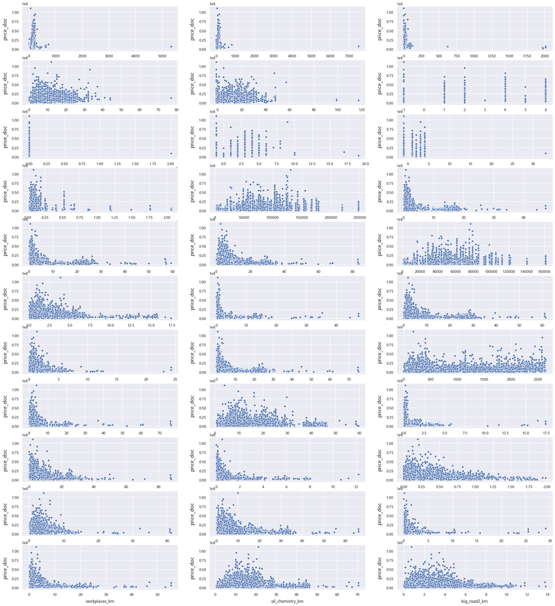

```python
numeric_dtypes = ['int16', 'int32', 'int64', 'float16', 'float32', 'float64']
numeric = []
for col in new_data.columns:
    if new_data[col].dtype in numeric_dtypes:
        numeric.append(col)
    else:
        pass
numeric.remove('price_doc')
fig, axs = plt.subplots(ncols=2, figsize=(12, 40))

# 调整子图布局 Adjusting the layout of subplots
plt.subplots_adjust(right=2,top=2)
sns.color_palette("husl", 8)


for i, feature in enumerate(list(new_data[numeric]),1):
    plt.subplot(len(list(numeric)), 3, i)
    sns.scatterplot(x=feature,y='price_doc',palette='Blues',data=new_data)
    plt.xlabel('{}'.format(feature),size=12,labelpad=8)
    plt.ylabel('price_doc', size=15, labelpad=12)

plt.show()
```

这里使用散点图查看了数值型特征与价格的一个大概趋势 Scatter plots are used to determine a general trend of numerical features and prices, 1、可以看到数值类特征上端均有异常值，数据多数不符合正太分布。 It can be seen that there are outliers on all of the numerical class features and that most of the data does not conform to a normal distribution. 2、考虑到在上面处理缺失值的时候填充了大量-1，会使所填充的特征中呈现偏峰分布，所以这里应该忽视上面已填充的特征类别，对本是数值类型的特征进行处理异常值，考虑到上面的相关性，决定处理“full_sq”、“life_sq” Considering that a large number of -1s were filled in the above missing values, it will caused a skewed peak distribution, 所以这里应该忽视上面已填充的特征类别，and the outliers should be processed for the features that are originally numerical types, considering the relevance of the above, it was decided to handling "full_sq", "life_sq". Next, the IQR(Interquartile range) method was used to filter the reasonable data.

```python
def outliners(data,col,scale=3):
    def box_plot_outliners(data_ser,box_scale):
        IQR=box_scale*(data_ser.quantile(0.75)-data_ser.quantile(0.25))
        val_low=data_ser.quantile(0.25)-IQR
        val_up=data_ser.quantile(0.75)+IQR
        return val_low,val_up
    data_n=data.copy()
    data_series=data_n[col]
    val_low,val_up=box_plot_outliners(data_series,box_scale=scale)
    data_n = data_n[(data_n[col]>val_low)&(data_n[col]<val_up)]
    return data_n
```

```python
new_data.shape
```

```
(30471, 38)
```

```python
data_new = outliners(new_data,'full_sq',scale=3)
```

```python
data = outliners(data_new,'life_sq',scale=3)
```

```python
data.shape
```

```
(23821, 38)
```

The above result shows a comparison of the quantities obtained before and after the outliers were removed.

#### 重复值 Duplicate value

```python
data.drop_duplicates(inplace=True)
```

```python
data.shape
```

```
(23819, 38)
```

#### 数据转换 Data transform

```python
data['timestamp'] = pd.to_datetime(data['timestamp'], format = '%Y-%m-%d')
data['big_market_raion'] = data['big_market_raion'].map({'yes':1,'no':0})
```

```python
from datetime import datetime
data["year"] = data['timestamp'].dt.year
data["month"] = data['timestamp'].dt.month
data["day"] = data['timestamp'].dt.day
data["weekday"] = data['timestamp'].dt.weekday
```

```python
data.to_csv('ddd.csv',header=True)
```

以上对"timestamp"特征进行了转换格式，并且构建了四个新特征，对“big_market_raion”特征进行了二值化。 The "timestamp" feature has been re-formatted and four new features have been constructed, and the "big_market_raion" feature has been binarised.

## 数据探索性分析 Exploratory analysis of data

### “price_doc” overview

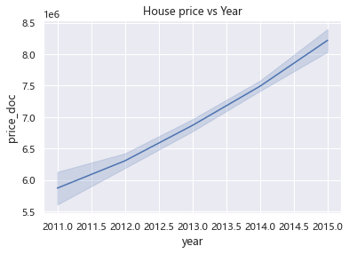

```python
sns.lineplot(x=data['year'], y=data['price_doc'], data=data)
plt.title('House price vs Year')
```

从上图可以看到，年份与销售金额是正相关的，也就是说，房屋价格在逐年上升。 From the above graph, it can be clearly seen that the year is positively correlated with the sold price, meaning that the price of a property is increasing year on year.

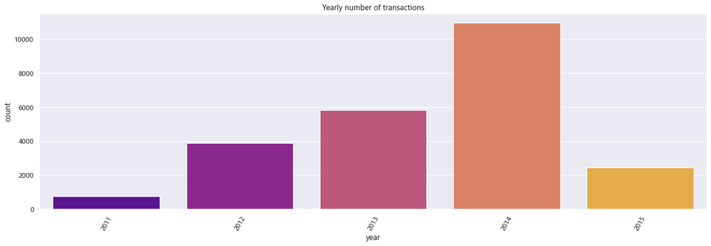

```python
sns.countplot(data['year'], palette="plasma")
plt.xticks(rotation=60)
fig = plt.gcf()
plt.title('Yearly number of transactions')
fig.set_size_inches(20,6)
```

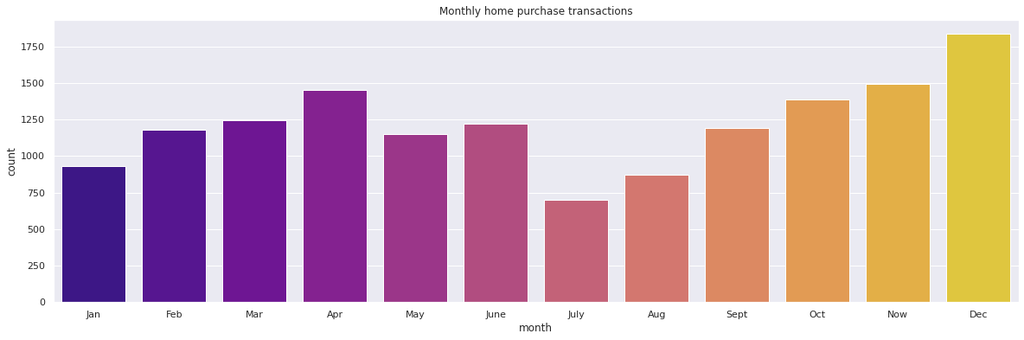

```python
sns.countplot(data['month'], palette="plasma")
plt.xticks(rotation=60)
fig = plt.gcf()
plt.xticks(range(0,12),['Jan','Feb','Mar','Apr','May','June','July','Aug','Sept','Oct','Now','Dec'],rotation = 0)
plt.title('Monthly home purchase transactions')
fig.set_size_inches(20,6)
```

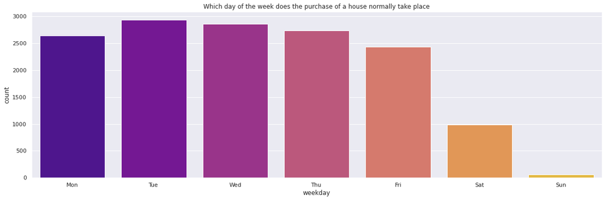

```python
sns.countplot(data['weekday']+1, palette="plasma")
plt.xticks(rotation=60)
fig = plt.gcf()
plt.xticks(range(0,7),['Mon','Tue','Wed','Thu','Fri','Sat','Sun'],rotation = 0)
plt.title('Which day of the week does the purchase of a house normally take place')
fig.set_size_inches(20,6)
```

从上面我们可以知道

1、俄罗斯房价从2011-2014年都是在上升，但是到2014年之后，数量就骤降，可以猜到，在2014年一定发生了什么事情，导致买房减少，查阅资料发现，2014年乌东问题及西方制裁前，莫斯科房价一路走高，此情况持续一段时间，但在2014年之后，由于受到政治因素影响，买房的数量减少。 Russian house prices were on the rise from 2011-2014, Moscow house prices went all the way up and this situation lasted for a while until 2014. After that the transaction numbers plummeted, which is led by Russian financial crisis in 2014. 2、每年购房高峰期在3-4月和11-12月份。 The peak buying periods each year are March-April and November-December

3、购房一般发生在工作日，这和我预期的不太一样，我以为买家周六周日购房会多一些。